# Egzaminas

Milda Pieškutė

2017 m sausis 20 d

## Užduotis 1

Sugeneruokite x su pateiktu R kodu.

set.seed(1234567890) x <- rnorm(5000)

```r
set.seed(1234567890)
x <- rnorm(5000)
```

1. Suraskite x vidukio ir standartinio nuokrypio įverčius.

```r
mean(x)
```

```
## [1] -0.008801267
```

```r
sd(x)
```

```
## [1] 1.006349
```

2. Raskite x išskirtis. Šioje užduotyje, išskirtimis laikome reikšmes, kurios nepakliūna į intervalą
   $$[\bar{X} - 3\hat{sd}]; \bar{X} + 3\hat{sd}].$$
   Čia $\bar{X}$ ir $\hat{sd}$ atitinkamai žymi vidukio ir standartinio nuokrypio įverčius. Atsakymui pateikite ir reikšmes, ir atitinkamus reikšmių indeksus.

```r
a<-((mean(x)-3*sd(x))>x|(mean(x)+3*sd(x))<x)

table(a)
```

```
## a
## FALSE  TRUE
##  4988    12
```

```r
which(a,TRUE)
```

```
##  [1]  473  811 1221 1480 2286 2329 2553 2609 3351 3835 3924 4123
```

```r
reiksmes<-x[c(which(a,TRUE))]
```

3. Pašalinkite rastas išskirtis iš x vektorius ir nubrėžkite atnaujinto x histogramą.

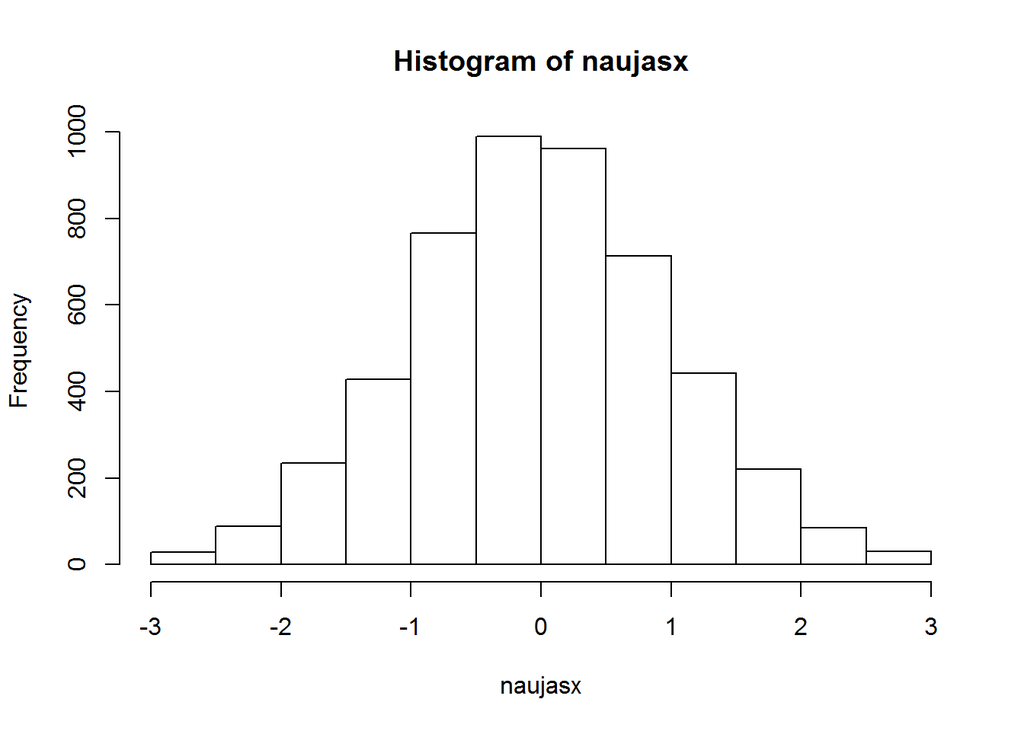

```r
naujasx<-x[-c(which(a, TRUE))]
hist(naujasx)
```

## Užduotis 2 (numatyta 20 taškų)

Tarkime $X_1$ ir $X_2$ yra nepriklausomi, $X_1 \sim N(3, 2)$, $X_2 \sim N(-1, 3)$ ir $X = X_1 + X_2$.

1. Raskite $X$ teorinį skirstinį. Išbrėžkite tankio grafiką. Pastaba: labai naudinga savybė, kad dviejų natūraliųjų dydžių suma taip pat yra natūralusis dydis.

Iš teorijos žinome, kad dviejų normaliųjų atsitiktinių dydžių sumos skirstinys yra miu1+miu2, sugma1+sigma2

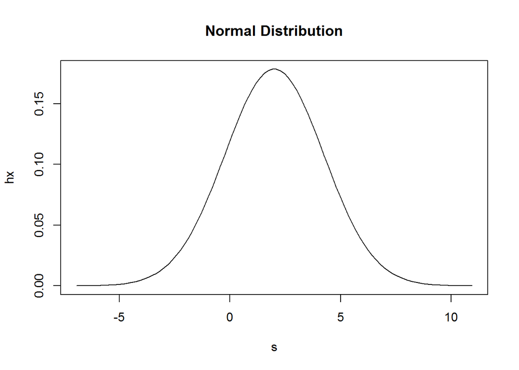

```r
miu=3+(-1)
sigma=2+3
Xteor<-rnorm(10^5,miu, sqrt(sigma))

density(Xteor)->dteor

s <- seq(-4,4,length=100)*sqrt(sigma) + miu
hx <- dnorm(s,miu,sqrt(sigma))

plot(s, hx, type="l",main="Normal Distribution")->m
```

2. Sugeneruokite $X$ imtį ($N=10000$) pagal pateiktą $X$ apibrėžimą.

```r
n=10000
x1<-rnorm(n,3,sqrt(2))
x2<-rnorm(n,-1,sqrt(3))
X<-x1+x2
```

3. Palyginkite sugeneruotą $X$ empirinį skirstinį su teorinį skirstiniu. Palyginimui pateikite tankių grafikus ir skirstinių charakteristikas (vidurkį, medianą ir standartinį nuokrypį).

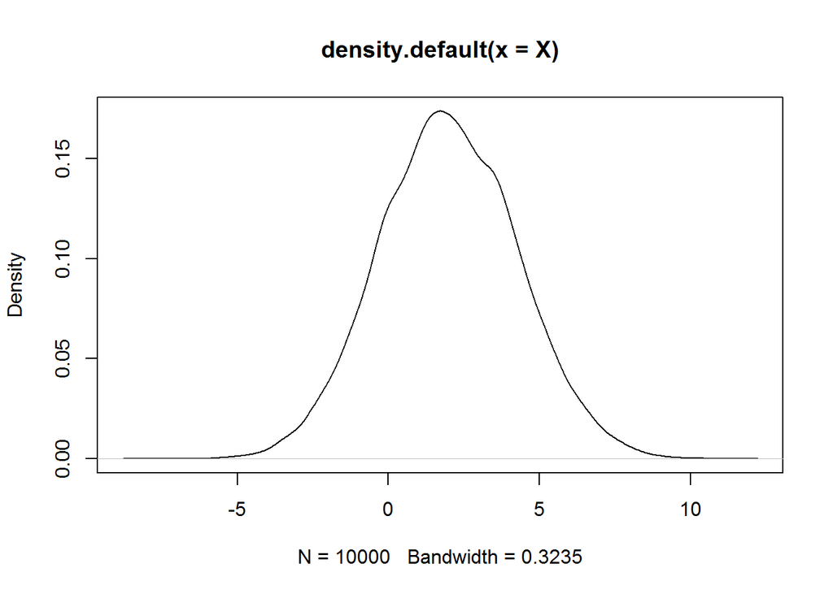

```r
density(X)->d
plot(d)
```

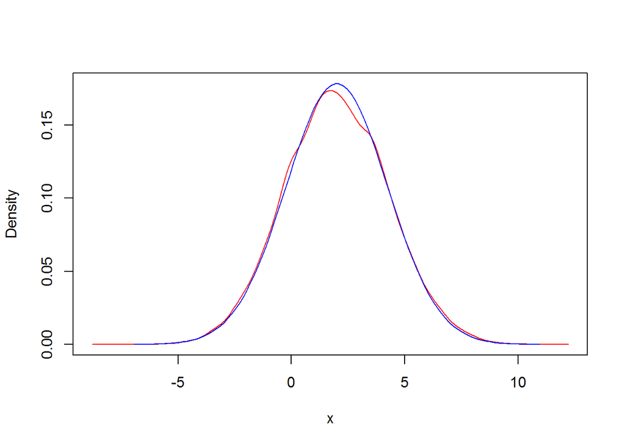

```r
plot(range(d$x, dteor$x), range(d$y, dteor$y), type = "n", xlab = "x",ylab = "Density")
lines(d, col = "red")
lines(s, hx, col = "blue")
```

Mėlyna teorinio tankis, raudona- empirinio.

```r
summary(X)
```

```
##    Min. 1st Qu.  Median    Mean 3rd Qu.    Max.
##  -7.816   0.413   1.952   1.986   3.542  11.240
```

Teorinio vidurkis 2, mediana 2, standartinis nuokrypis kvadratine saknis is 5.

4. Raskite teorinę įvykio $|X| > 2$ tikimybę (konkreti neatsitikinė konstanta).

```r
pnorm(-2, mean =miu, sd=sqrt(sigma))+1-pnorm(2, mean =miu, sd=sqrt(sigma))
```

```
## [1] 0.5368191
```

5. Įvertinkite įvykio $|X| > 2$ tikimybę naudojantis Monte-Carlo metodu.

```r
n=10000
x1<-rnorm(n,3,sqrt(2))
x2<-rnorm(n,-1,sqrt(3))
X<-x1+x2
a<-X<(-2)|X>2
sum(a)/n
```

```
## [1] 0.5357
```

## Užduotis 3 (numatyta 30 taškų)

Faile ‘data_a.csv’ yra pateikti duomenys reikalingi tiesinės regresijos tyrimui. Duomenų masyvo aprašymas pateiktas minėto failo pradžioje.

Duomenų apžvalga ir paruošimas. Šioje dalyje jums reikia susipažinti su duomenimis ir paruošti duomenis tolimesnei analizei.

1. Nuskaitykite duomenų masyvą. Jeigu įmanoma, nekoreguokite originalaus failo.

```r
datafull<-read.csv2("https://raw.githubusercontent.com/1vbutkus/Econometrics1/master/Egzaminas/data.csv", stringsAsFactors = FALSE, header = TRUE, comment.char = "%")
head(datafull)
```

```
##     kaina             rida  amzius galia markesKodas
## 1 12770.1 164110.850559981      11    55          qt
## 2 15180.7 673467.350444128      12    55          ky
## 3 17591.9 494773.347639264      15    75          ky
## 4   19854 360467.882751469       2    65          qt
## 5    5574 601594.656948206 MISSING    55          bm
## 6 22996.3 377599.274933091       5    65          ky
```

```r
dim(datafull)
```

```
## [1] 352   5
```

2. Paruoškite duomenis naudojimui. Jūs turite užtikrinti, kad:

Neliko įrašų su trūkstamomis reikšmėmis - jeigu šalinote įrašus, tai būtinai raportuokite kiek įrašų pašalinta ir kiek liko.

Duomenų masyve nėra kažkokių klaidų (pvz. negalimos reikšmės, neteisingas duomenų tipas, t.t.). Patartina patikrinti visų duomenų tipus, nes kartais nuskaitymo procedūra suinterpretuoja duoenis ne taip kaip tikimasi.

```r
ind<-datafull$amzius%in%c("MISSING")
datafull<-datafull[!ind,]
head(datafull)
```

```
##     kaina             rida amzius galia markesKodas
## 1 12770.1 164110.850559981     11    55          qt
## 2 15180.7 673467.350444128     12    55          ky
## 3 17591.9 494773.347639264     15    75          ky
## 4   19854 360467.882751469      2    65          qt
## 6 22996.3 377599.274933091      5    65          ky
## 7 33282.1 347404.826805315      2    65          ky
```

```r
ind<-datafull$kaina%in%c("MISSING")
datafull<-datafull[!ind,]
ind<-datafull$galia%in%c("MISSING")
datafull<-datafull[!ind,]
ind<-datafull$rida%in%c("MISSING")
datafull<-datafull[!ind,]
ind<-datafull$markesKodas%in%c("MISSING")
datafull<-datafull[!ind,]
sapply(datafull, class)
```

```
##       kaina        rida      amzius       galia markesKodas
## "character" "character" "character"   "integer" "character"
```

```r
datafull$kaina<-as.numeric(datafull$kaina)
datafull$rida<-as.numeric(datafull$rida)
datafull$galia<-as.numeric(datafull$galia)

sapply(datafull, class)
```

```
##       kaina        rida      amzius       galia markesKodas
##   "numeric"   "numeric" "character"   "numeric" "character"
```

```r
dim(datafull)
```

```
## [1] 347   5
```

```r
352-347# kiek įrašų pašalinom
```

```
## [1] 5
```

3. Pateikite trumpą kintamųjų apžvalgą. Naudokite tik tuos duomenis (ir kintamuosius), kuriuos planuojate taikyti tyrimui, t.y. jei reikėjo ką nors modifikuoti, tai senųjų reikšmių naudoti nebereikia. Šiai apžvalgai užtenka informacijos, kurią pateikia funkcijos plot, summary ir cor.

```r
datafull<-datafull[,c(1,2,4)]
cor(datafull)
```

```
##             kaina        rida       galia
## kaina  1.00000000 -0.37914830 -0.09252369
## rida  -0.37914830  1.00000000 -0.02700813
## galia -0.09252369 -0.02700813  1.00000000
```

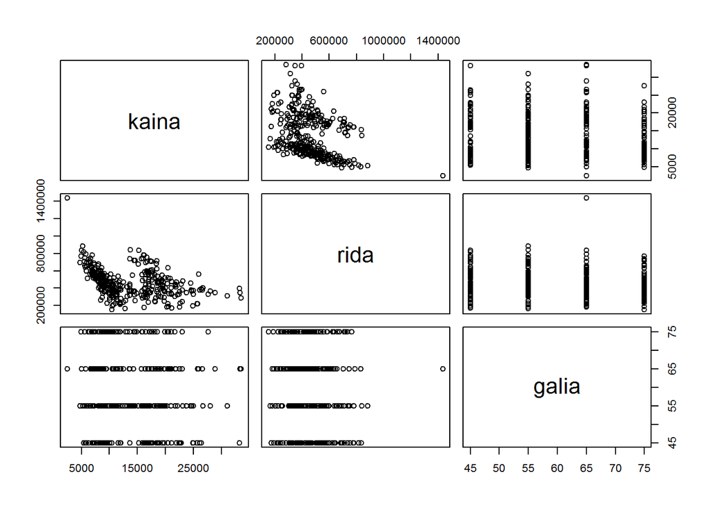

```r
plot(datafull)
```

4. Duomenų masyvą suskaidykite į du atskirus ir nesikertančius masyvus. Didesnį masyvą turi sudaryti apie 80 proc. turimų stebėjimų. Šį masyvą vadinsime trainSet. Mažesnį masyvą turi sudaryti likę įrašai. Šį masyvą vadinsime testSet. Duomenų suskaidymas turi būti atsitiktinis. Gali būti naudingos šios funkcijos:sample, setdiff, %in%.

```r
n <- length(datafull)

ind <- sample(c(TRUE, FALSE), n, replace=TRUE, prob=c(0.8, 0.2))
trainSet <- datafull[ind, ]
testSet <- datafull[!ind, ]
```

Tiesinio modelio sudarymas. Modelio sudarymui naudokite trainSet masyvą.

1. Įvertinkite tiesinį modelių, kuriame prognozuojamas kintamasis būtų kaina. Ji turi tiesiškai priklausyti nuo kitų kintamųjų.

```r
mod1<-lm(kaina~rida+galia, trainSet)
summary(mod1)
```

```
##
## Call:
## lm(formula = kaina ~ rida + galia, data = trainSet)
##
## Residuals:
##    Min     1Q Median     3Q    Max
##  -7498  -4638  -2232   4632  17890
##
## Coefficients:
##               Estimate Std. Error t value Pr(>|t|)
## (Intercept)  2.230e+04  2.307e+03   9.664  < 2e-16 ***
## rida        -1.074e-02  2.311e-03  -4.649 5.65e-06 ***
## galia       -6.183e+01  3.406e+01  -1.815   0.0708 .
## ---
## Signif. codes:  0 '***' 0.001 '**' 0.01 '*' 0.05 '.' 0.1 ' ' 1
##
## Residual standard error: 5459 on 229 degrees of freedom
## Multiple R-squared:  0.09789,    Adjusted R-squared:  0.09001
## F-statistic: 12.42 on 2 and 229 DF,  p-value: 7.537e-06
```

2. Ar visi įtraukti kintamieji daro reikšmingą įtaką prognozei? Jei ne, koreguokite modelį, kad visi kintamieji darytų reikšmingą įtaką. Šį įvertintą modelį žymėsime fit. Užrašykite šio modelio matematinę lygtį.

```r
fit<-mod1
```

```r
shapiro.test(fit$res)
```

```
##
##  Shapiro-Wilk normality test
##
## data:  fit$res
## W = 0.9062, p-value = 6.95e-11
```

Pagal shapiro.test p-value<0.05 atmetamame H0: liekanų paklaidos nera normalios. Modelių palyginimas ir prognozė.

1. Suskaičiuokite modelio fit1 RMSE (Root Mean Squere Error), kuris apibrėžiamas taip
   $$RMSE = \sqrt{\frac{1}{n} \sum_{i=1}^n \varepsilon_t^2}.$$

```r
rmse <- function(error)
{
    sqrt(mean(error^2))
}


rmse(fit$residuals)
```

```
## [1] 5423.279
```

RMSE suskaičiuokite abiem duomenų masyvams trainSet ir testSet. Rezultatus sudėkite į lentelę. Palyginkite rezultatus ir padarykite išvadas.

```r
pre<-predict(fit,trainSet)
error1<-trainSet$kaina-pre
rmse(error1)->e1


pre2<-predict(fit,testSet)
error2<-testSet$kaina-pre2
rmse(error2)->e2

levels<-factor(c("trainSet", "testSet"))

bubba<-data.frame(trainSet=e1, testSet=e2)
bubba
```

```
##   trainSet  testSet
## 1 5423.279 5713.344
```

Rezultatai beveik sutampa.

2. Išbrėžkite sklaidos diagramą, kurioje $x$ ašyje būtų fit1 modelio testSet prognozė, o $y$ ašyje faktinės testSet kainų reikšmės. Ant šios sklaidos diagramos išbrėžkite dvi linijas, kurios žymėtų prognozės pasikliautinus intervalus (pasikliovimo lygmuo 90 proc.).

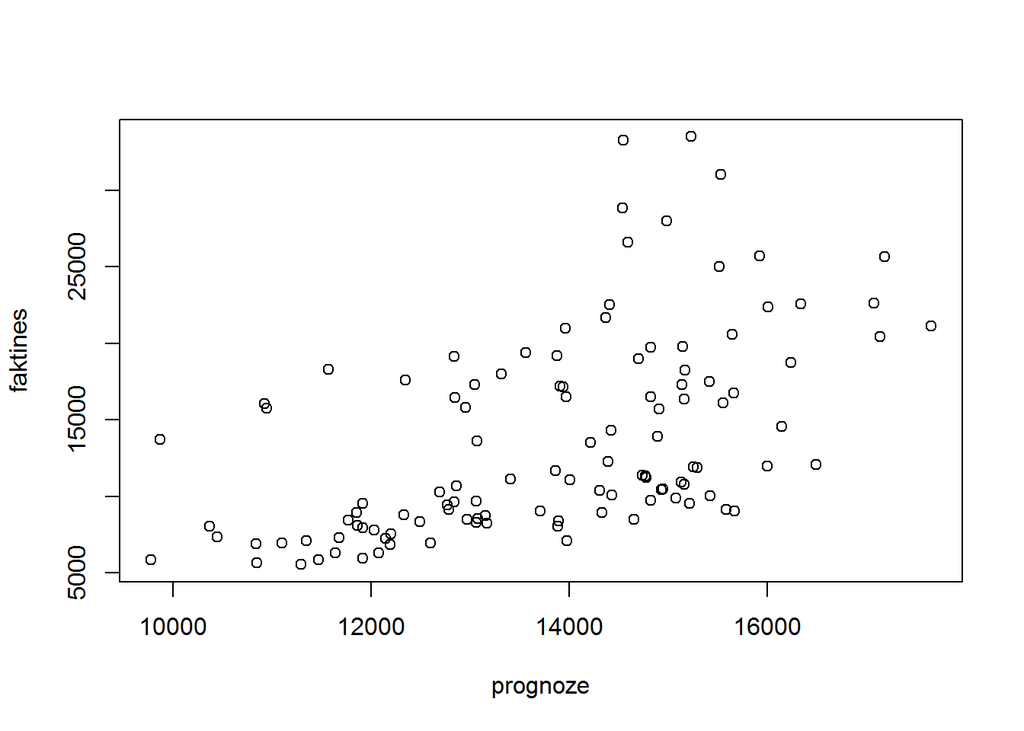

```r
plot(pre2, testSet$kaina, xlab = "prognoze", ylab = "faktines")
```

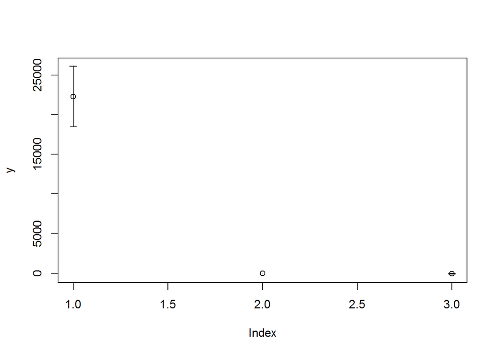

```r
y = coef(fit)
x = seq_along(y)
confint(fit, level=0.90)->ci
plot(y, ylim=range(ci))
arrows(x,ci[,1],x,ci[,2], code=3, angle=90, length=0.05)
```

3. Kiek procentų prognozuotų reikšmių nepateko į pasikliautinus intervalus?